```python
#Name(s) here
# Simon Weisser
```

# Association Analysis

Association analysis uses machine learning algorithms to extract hidden relationships from large datasets. In this assignment we'll be using one of the most commonly used algorithms for association rule mining - the Apriori algorithm.

The data we'll use comes from a bakery called "The Bread Basket", located in the historic center of Edinburgh. The dataset contains more than 9000 transactions from the bakery. The file contains the following columns:

- Date. Categorical variable that tells us the date of the transactions (YYYY-MM-DD format). The column includes dates from 2016-10-30 to 2017-04-09.
- Time. Categorical variable that tells us the time of the transactions (HH:MM:SS format).
- Transaction. Quantitative variable that allows us to differentiate the transactions. The rows that share the same value in this field belong to the same transaction.
- Item. Categorical variable with the products purchased.

## Installation

`scikit-learn` does not provide any functionality for association rule mining so for this assignment you will be using the `MLxtend` library. The documentation for this library is available [here](http://rasbt.github.io/mlxtend/).

You will need to install the `MLxtend` library. There are several ways of doing this; you can follow the instructions below, or see the setup guide [here](http://rasbt.github.io/mlxtend/installation/).

### Conda

Most of you should use Conda to do the install. If you downladed Anaconda in order to get Jupyter Notebooks (which is the most common way to get Jupyter Notebooks), then you will want to install `MLxtend` using Conda.

Open a command prompt / terminal window and type:

`conda install mlxtend --channel conda-forge`

### PyPi

You can also install via pip. Note: If you are running Jupyter notebooks through an Anaconda install, then pip may not place the `MLxtend` libraries in the correct place for use in Jupyter.

Open a command prompt / terminal window and type:

`pip3 install mlxtend`

## Apriori Algorithm

The Apriori algorithm is a classical algorithm in data mining. It is used for mining frequent itemsets and relevant association rules. In this part, you'll be running this algorithm for generating the itemsets that occur more than the `min_sup` threshold. Based on these frequent itemsets you'll find association rules that have confidence above the `min_conf` threshold.

```python
# Standard imports (you can add additional headers if you wish)
import numpy as np
import pandas as pd
import matplotlib.pyplot as plt
from mlxtend.preprocessing import TransactionEncoder
from mlxtend.frequent_patterns import apriori
from mlxtend.frequent_patterns import fpmax
from mlxtend.frequent_patterns import association_rules
```

```python
%matplotlib inline
```

```python
# Reading the dataset from file
def load_dataset(file_name):
    with open(file_name, 'r') as f:
        content = f.readlines()[1:]
    transactions = []
    prev_tid = -1
    for t in content:
        t = t.strip().split(',')[-2:]
        tid = t[0]
        item = t[1]
        if prev_tid != tid:
            prev_tid = tid
            transactions.append([item])
        else:
            transactions[-1].append(item)
    return transactions
```

```python
dataset = load_dataset('BreadBasket_DMS.csv')
#dataset is a 2D list
print("Num transactions:", len(dataset))
#Print the first 10 transactions
dataset[:10]
```

```
Num transactions: 9531
```

```
[['Bread'],
 ['Scandinavian', 'Scandinavian'],
 ['Hot chocolate', 'Jam', 'Cookies'],
 ['Muffin'],
 ['Coffee', 'Pastry', 'Bread'],
 ['Medialuna', 'Pastry', 'Muffin'],
 ['Medialuna', 'Pastry', 'Coffee', 'Tea'],
 ['Pastry', 'Bread'],
 ['Bread', 'Muffin'],
 ['Scandinavian', 'Medialuna']]
```

**Q1.** Many transactions in the dataset include the item "NONE." First, find and remove all the "NONE" items from the dataset.

Once you have removed the NONEs, find the top 10 best-selling items in the bakery. Create a bar chart to display the total number of transactions for each of the top 10 selling items. Sort the bar chart by frequency (the top most sold item first, down to the 10th most sold item).

[output not shown]

[output cut: 680 more lines]

```
['Toast', 'Coffee', 'Bread']
['Coffee', 'Bread', 'Tea', 'Pastry', 'Muffin']
['Alfajores', 'Tea']
['Coffee', 'Coffee', 'Medialuna', 'Cookies', 'Tiffin', 'Toast']
['Coffee', 'Tea']
['Coke', 'Soup', 'Sandwich', 'Tea', 'Mineral water']
['Chicken Stew', 'Sandwich']
['Afternoon with the baker', 'Argentina Night', 'Tea']
['Truffles', 'Coffee', 'The Nomad']
['Coffee', 'Tea', 'Smoothies', 'Spanish Brunch', 'The Nomad']
['Sandwich', 'Spanish Brunch', 'Tea', 'Juice']
['Coffee']
['Bread', 'Sandwich', 'Sandwich']
['Coffee', 'Cookies', 'Extra Salami or Feta']
10 Top Selling Items = [('Coffee', 5471), ('Bread', 3325), ('Tea', 1435), ('Cake', 1025), ('Pastry', 856), ('Sandwich', 771), ('Medialuna', 616), ('Hot chocolate', 590), ('Cookies', 540), ('Brownie', 379)]
```

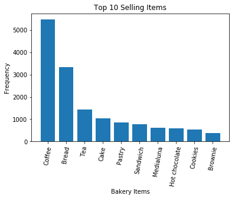

```python
# your code goes here
for item in dataset:
    if len(item) == 1 and 'NONE' in item:
        dataset.remove(item)
    if 'NONE' in item:
        item.remove('NONE')
        print(item)

dict = {}
for item in dataset:
    for good in item:
        if good not in dict.keys():
            temp_dict = {good:1}
            dict.update(temp_dict)
        else:
            dict[good] += 1
sorted_d = sorted(dict.items(), key=lambda x: x[1])
top_selling = sorted_d[-10:]
top_selling = top_selling[::-1]
print("10 Top Selling Items =", top_selling)

plt.bar(range(len(top_selling)), [val[1] for val in top_selling], align='center')
plt.xticks(range(len(top_selling)), [val[0] for val in top_selling])
plt.xticks(rotation=80)
plt.xlabel('Bakery Items')
plt.ylabel('Frequency')
plt.title('Top 10 Selling Items')
plt.show()
```

**Q2.**

a.) Using `mlxtend.preprocessing.TransactionEncoder` transform `dataset` into an array format suitable for the `mlxtend` library. You will need to call `fit` then `transform`.

`TransactionEncoder` learns unique items from the dataset and transforms each transaction into a one-hot encoded boolean numpy array. For example, the resulting encoded dataset will be represented by something like this, where each row is a transaction. If the first transaction contained ['Crepe', 'Jam'], this would correspond to the first row in the encoded table.

[figure not shown]

Print the `shape` of the resulting encoded numpy array.